# Bering Sea ESR vs ESP comparison

Matt Callahan

2022-09-14

## Overview

As of mid September 2022, we have submitted 3 ESP indicator as well as our draft contribution to the Bering Sea ESR. The Bering Sea ESR showed below average chlorophyll. Conversely, 2/3 ESP chla indicators were the highest in the time series. This document explores the following potential source of error of that variaton.

## Indicator descriptions

```r
library(tidyverse)
library(AKmarineareas)
library(sf)
library(lubridate)
#esr extent
bsesr<-AK_marine_area(area="Ecosystem Subarea")%>%
  filter(Ecosystem_Area=="Eastern Bering Sea")
# AMJ_Chlorophylla_Biomass_SEBS_Satellite extent
amj_bsierp<-AK_marine_area(area="BSIERP Region")%>%
  filter(BSIERP_Region_Name%in%c("St. Matthew","Pribilofs"))
#load crab polygons
crab<-st_read(dsn="../../chla-indicator-comparison/Data/GIS/AK_Crab_Management_Areas.gdb", layer="BS_King_Crab_dd")
```

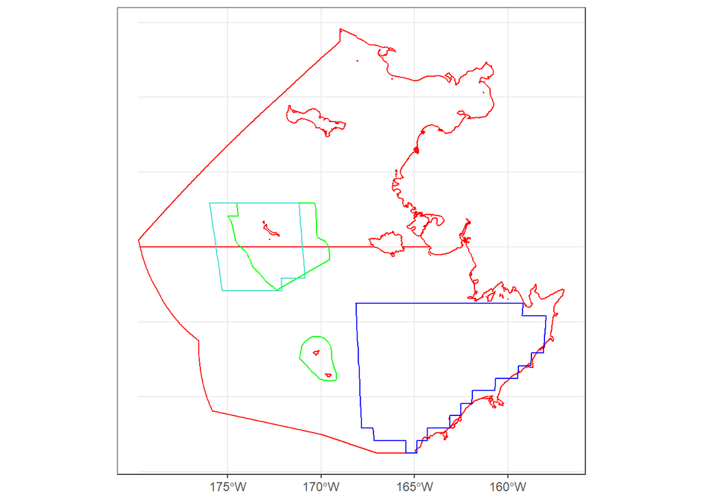

```r
#sebs_is
sebs_is<-crab%>%filter(BS_KING=="BBRKC")
stmatt<-crab%>%filter(BS_KING=="StMattBKC")

ggplot()+
  geom_sf(data=bsesr, color="red", fill=NA)+
  geom_sf(data=amj_bsierp, color="green", fill=NA)+
  geom_sf(data=sebs_is, color="blue", fill=NA)+
  geom_sf(data=stmatt, color="turquoise", fill=NA)+
  theme_bw()
```

## Examine spatial extents of bloom

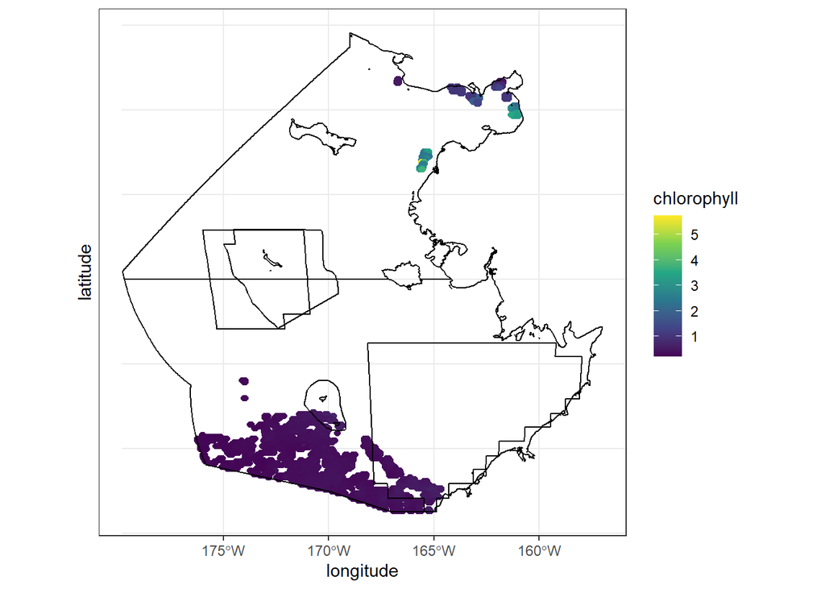

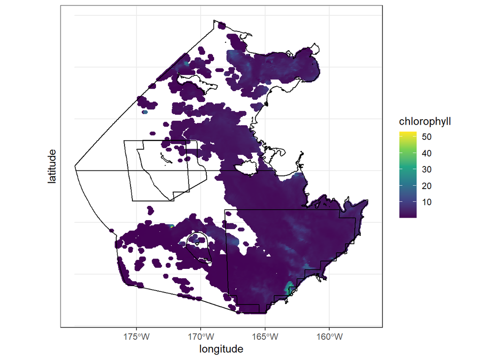

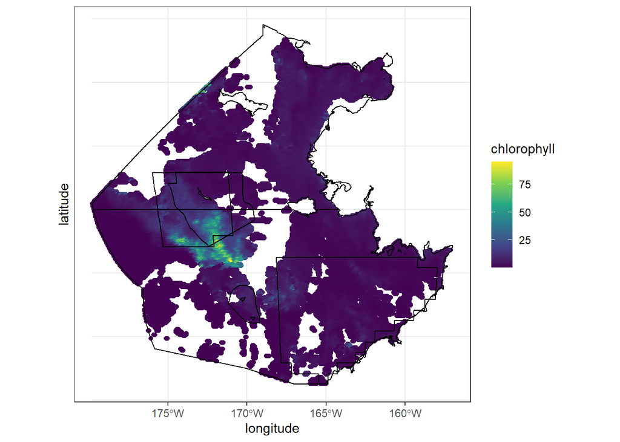

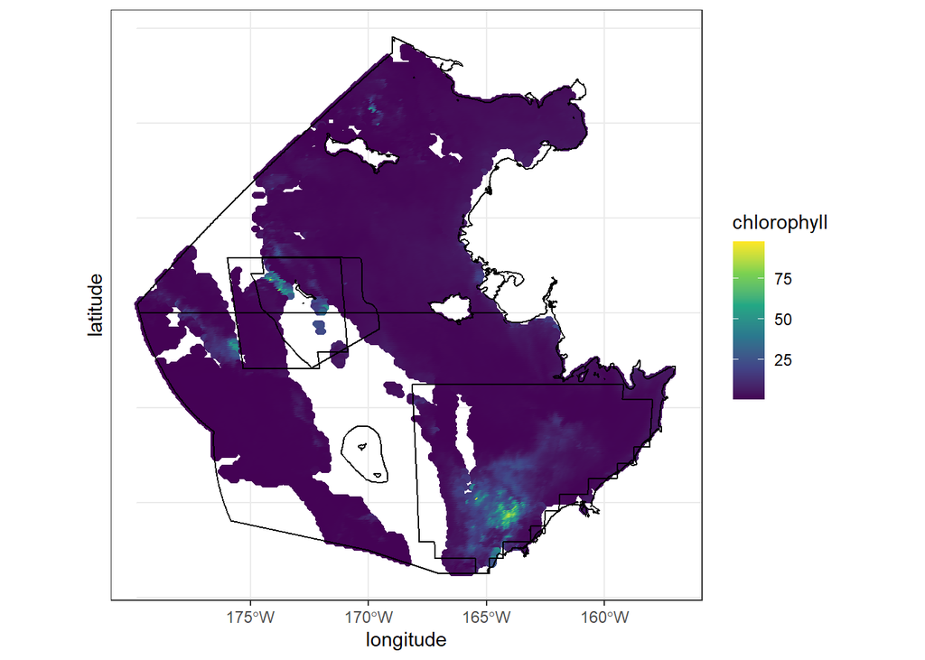

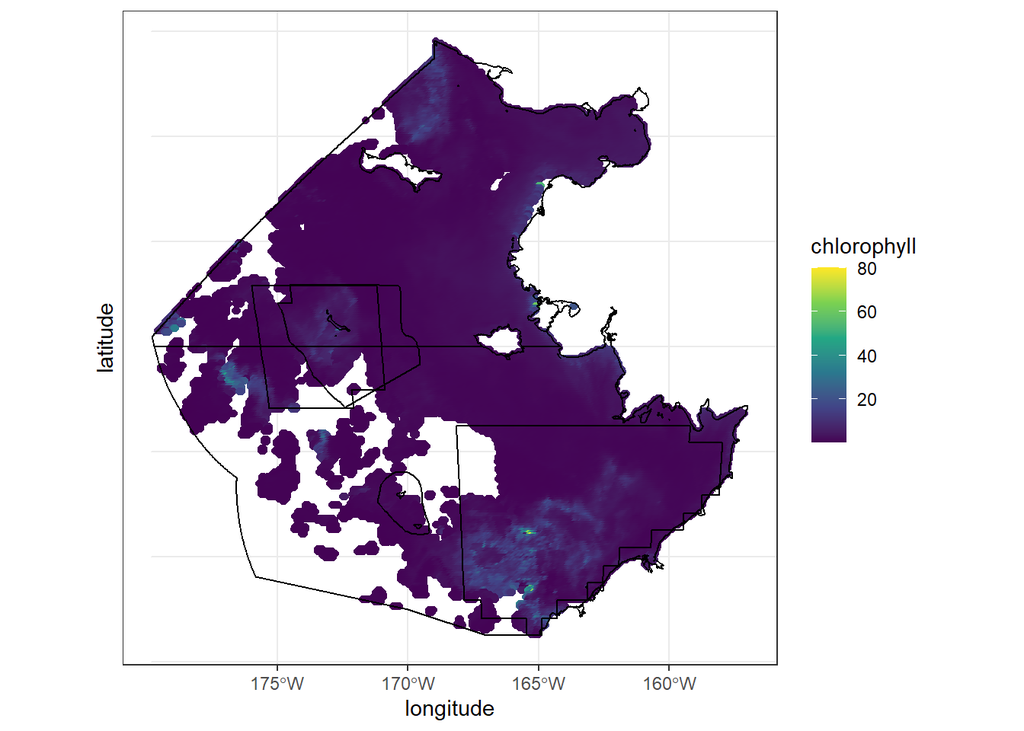

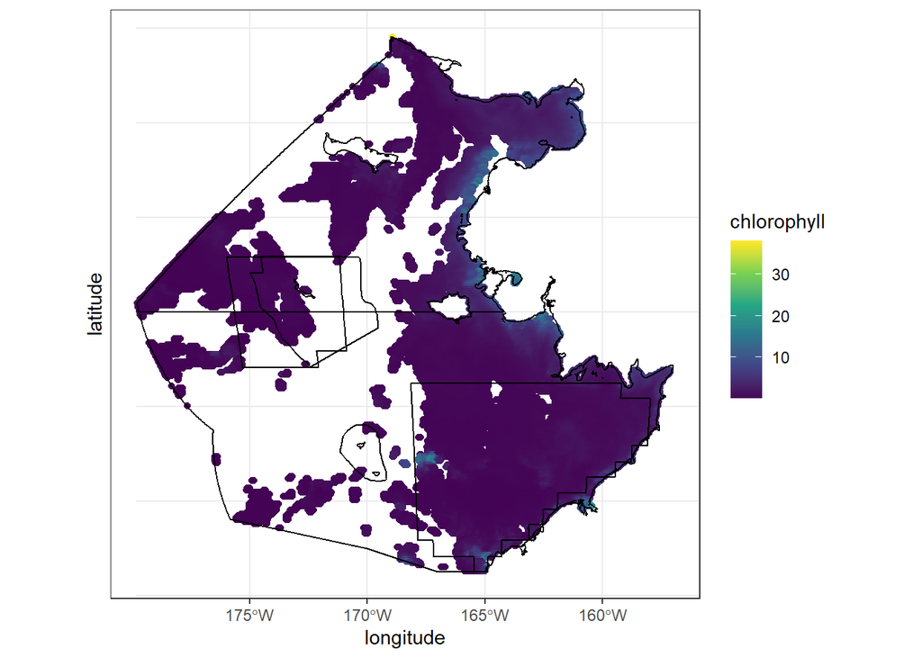

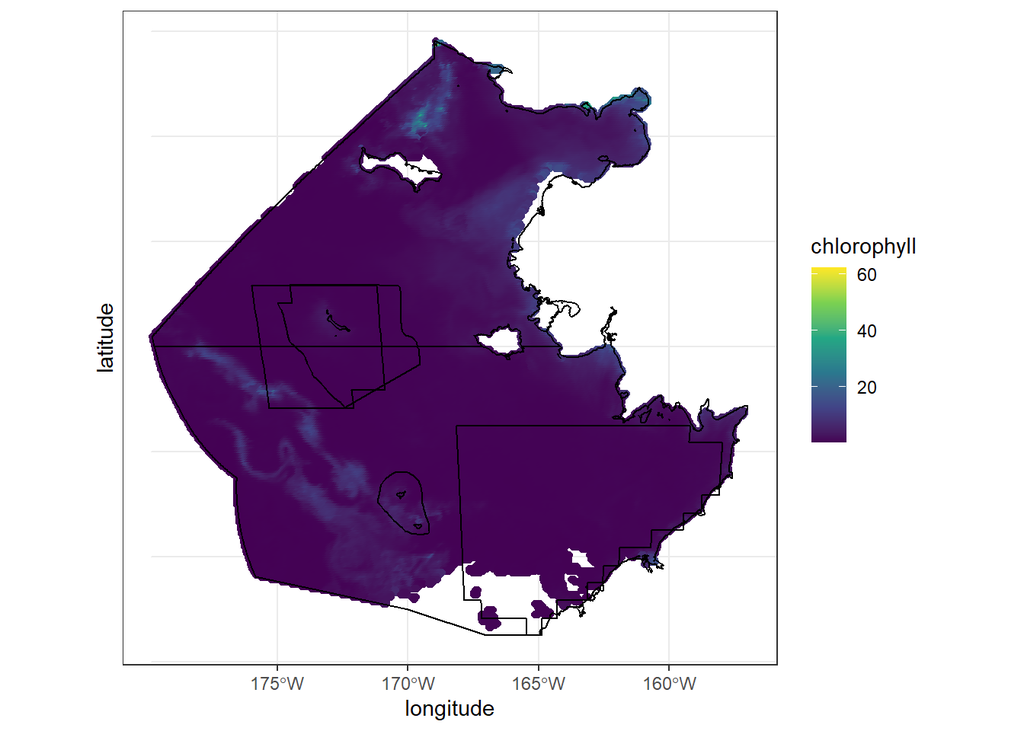

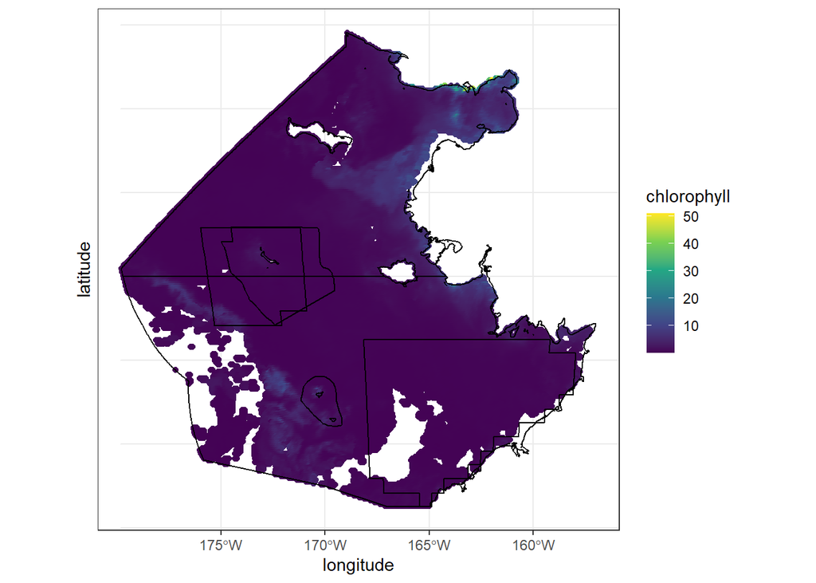

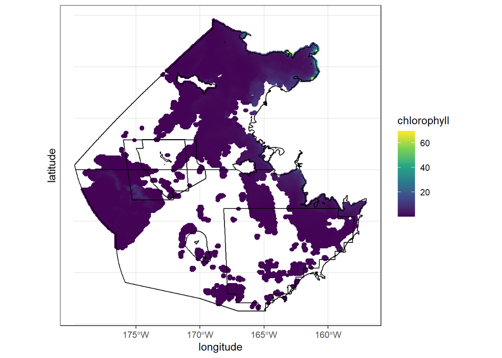

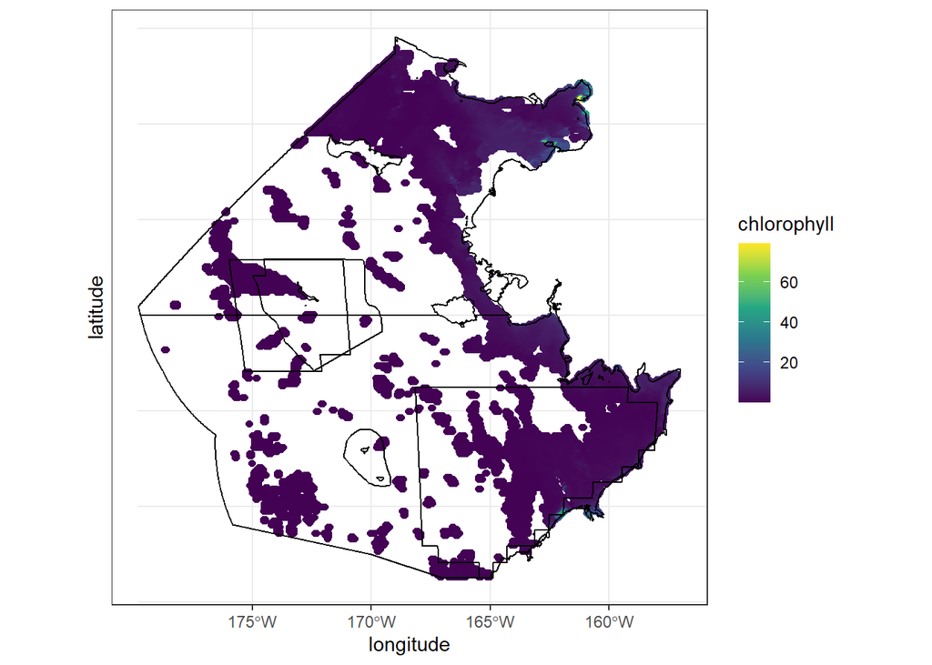

```r
#load chla
chla<-readRDS("../../chla-indicator-comparison/Data/MODIS/ESR/mod_bs.RDS")%>%
  rename_with(tolower)%>%
  filter(month %in% c(4:6))%>%
  mutate(date=date(date))

chla22<-chla%>%filter(year==2022)

#plot blooms
bloomplot<-function(m){ggplot()+
  geom_point(data=chla22%>% filter(date==m & longitude<0),
             aes(x=longitude, y=latitude, color=chlorophyll))+
  geom_sf(data=bsesr, color="black", fill=NA)+
  geom_sf(data=amj_bsierp, color="black", fill=NA)+
  geom_sf(data=sebs_is, color="black", fill=NA)+
  geom_sf(data=stmatt, color="black", fill=NA)+
  scale_color_viridis_c()+
  theme_bw()}

lapply(unique(chla22$date), bloomplot)
```

## Coastal influence

Next I will recalculate the ESP indicators with the depth filters that are applied to the ESR data, and see if 2022 is still high.

```r
#AMJ_Chlorophylla_Biomass_SEBS_Satellite
#recalculate indicator
chla %>%
  filter(bsierp_region_name%in%c("St. Matthew",
                          "Pribilofs"
                          ) &
           depth > -200 &
           depth < -20 &
           waters_cod == "FED"
         ) %>%
  group_by(year) %>%
  summarise(amj_sebs=mean(chlorophyll,na.rm=TRUE))
```

```
## # A tibble: 20 x 2
##     year amj_sebs
##    <dbl>    <dbl>
##  1  2003    3.00
##  2  2004    3.15
##  3  2005    1.85
##  4  2006    1.39
##  5  2007    0.979
##  6  2008    1.49
##  7  2009    2.48
##  8  2010    1.97
##  9  2011    1.19
## 10  2012    1.15
## 11  2013    1.94
## 12  2014    1.80
## 13  2015    2.73
## 14  2016    1.75
## 15  2017    2.35
## 16  2018    2.44
## 17  2019    1.77
## 18  2020    2.85
## 19  2021    2.61
## 20  2022    3.46
```

```r
#Spring_Chlorophylla_Biomass_SEBS_Inner_Shelf_Satellite
#recalculate indicator
chla %>%
  filter(bs_king=="BBRKC" &
           depth > -200 &
           depth < -20 &
           waters_cod == "FED") %>%
  group_by(year) %>%
  summarise(sebs_is=mean(chlorophyll,na.rm=TRUE))
```

```
## # A tibble: 20 x 2
##     year sebs_is
##    <dbl>   <dbl>
##  1  2003    3.11
##  2  2004    3.79
##  3  2005    2.86
##  4  2006    1.96
##  5  2007    2.10
##  6  2008    2.17
##  7  2009    3.13
##  8  2010    4.20
##  9  2011    2.90
## 10  2012    2.85
## 11  2013    2.97
## 12  2014    4.28
## 13  2015    3.92
## 14  2016    2.35
## 15  2017    1.93
## 16  2018    2.08
## 17  2019    2.24
## 18  2020    2.52
## 19  2021    2.49
## 20  2022    2.31
```

```r
#Spring_Chlorophylla_Biomass_SMBKC_Satellite
#recalculate indicator
chla %>%
  filter(bs_king=="StMattBKC" &
           depth > -200 &
           depth < -20 &
           waters_cod == "FED") %>%
  group_by(year) %>%
  summarise(stmatt_mean=mean(chlorophyll,na.rm=TRUE))
```

```
## # A tibble: 20 x 2
##     year stmatt_mean
##    <dbl>       <dbl>
##  1  2003       3.94
##  2  2004       3.77
##  3  2005       2.09
##  4  2006       1.91
##  5  2007       0.792
##  6  2008       1.36
##  7  2009       2.50
##  8  2010       1.55
##  9  2011       1.17
## 10  2012       0.501
## 11  2013       1.21
## 12  2014       3.05
## 13  2015       2.78
## 14  2016       1.53
## 15  2017       3.40
## 16  2018       2.80
## 17  2019       2.09
## 18  2020       2.97
## 19  2021       3.22
## 20  2022       3.88
```

This coastal influence seemed to have minimal impact on the results, probably because the near shore count is a small component of the total chla.

```r
#1% State waters
chla %>%
  filter(bs_king=="StMattBKC")%>%
  group_by(waters_cod)%>%
  summarise(n=n())
```

```
## # A tibble: 2 x 2
##   waters_cod      n
##   <chr>       <int>
## 1 FED        439273
## 2 STATE        5055
```

```r
#2% depths excluded
chla %>%
  filter(bs_king=="StMattBKC")%>%
  mutate(depth2=ifelse(depth < -20 & depth > -200, "included", "excluded"))%>%
  group_by(depth2)%>%
  summarise(n=n())
```

```
## # A tibble: 2 x 2
##   depth2        n
##   <chr>     <int>
## 1 excluded  11217
## 2 included 433111
```

## Recalculate ESR

I will recalculate the ESR indicator using the same simple formulas as the ESP indicators to confirm that it is low.

```r
#calculate mean
chla %>%
  group_by(ecosystem_subarea) %>%
  summarise(chla_mean=mean(chlorophyll,na.rm=TRUE))
```

```
## # A tibble: 2 x 2
##   ecosystem_subarea       chla_mean
##   <chr>                       <dbl>
## 1 Northern Bering Sea          2.99
## 2 Southeastern Bering Sea      2.67
```

```r
#recalculate indicator
chla22 %>%
  group_by(ecosystem_subarea) %>%
  summarise(chla_2022=mean(chlorophyll,na.rm=TRUE))
```

```
## # A tibble: 2 x 2
##   ecosystem_subarea       chla_2022
##   <chr>                       <dbl>
## 1 Northern Bering Sea          2.45
## 2 Southeastern Bering Sea      2.40
```

Sure enough, esr region values are below average.

## Compare weekly ESR and ESP values

Just for fun I will plot the weekly values for these five indicators.

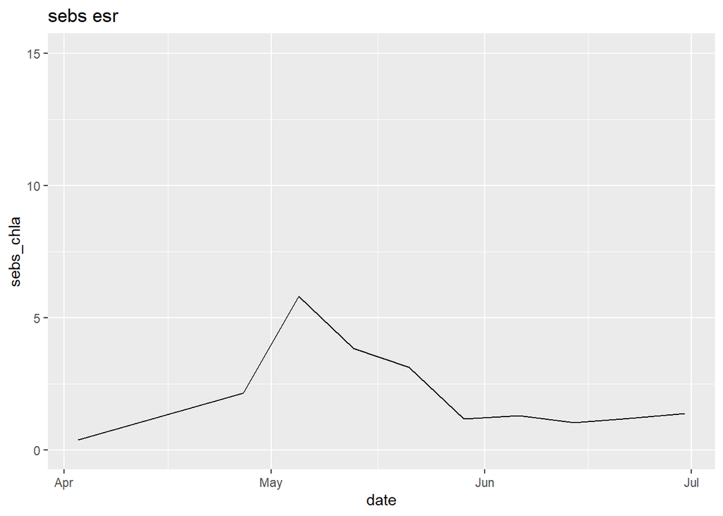

```r
p1<-chla22%>%
  filter(ecosystem_subarea=="Southeastern Bering Sea")%>%
  group_by(date)%>%
  summarize(sebs_chla=mean(chlorophyll,na.rm=TRUE))%>%
  ggplot()+
  geom_line(aes(x=date, y=sebs_chla))+
  ylim(c(0,15))+
  ggtitle("sebs esr")

p2<-chla22%>%
  filter(ecosystem_subarea=="Northern Bering Sea")%>%
  group_by(date)%>%
  summarize(nbs_chla=mean(chlorophyll,na.rm=TRUE))%>%
  ggplot()+
  geom_line(aes(x=date, y=nbs_chla))+
  ylim(c(0,15))+
  ggtitle("nbs esr")

p3<-chla22%>%
  filter(bsierp_region_name%in%c("St. Matthew",
                          "Pribilofs")
         ) %>%
  group_by(date) %>%
  summarise(amj_sebs=mean(chlorophyll,na.rm=TRUE))%>%
  ggplot()+
  geom_line(aes(x=date, y=amj_sebs))+
  ylim(c(0,15))+
  ggtitle("amj_sebs")

p4<-chla22%>%
 filter(bs_king=="BBRKC") %>%
  group_by(date) %>%
  summarise(sebs_is=mean(chlorophyll,na.rm=TRUE))%>%
  ggplot()+
  geom_line(aes(x=date, y=sebs_is))+
  ylim(c(0,15))+
  ggtitle("sebs is")

p5<-chla22%>%
  filter(bs_king=="StMattBKC") %>%
  group_by(date) %>%
  summarise(stmatt_mean=mean(chlorophyll,na.rm=TRUE))%>%
  ggplot()+
  geom_line(aes(x=date, y=stmatt_mean))+
  ylim(c(0,15))+
  ggtitle("stmatt")

p1
```

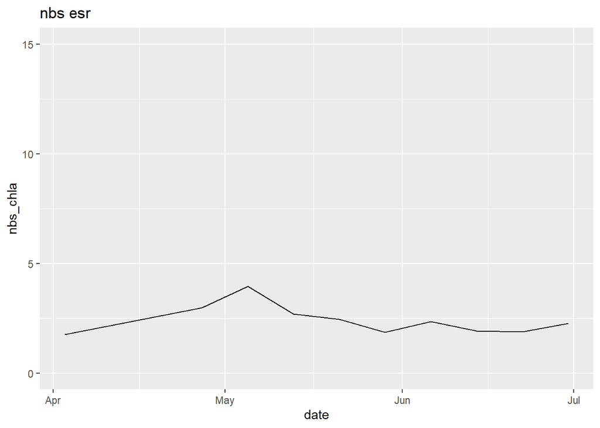

```r
p2
```

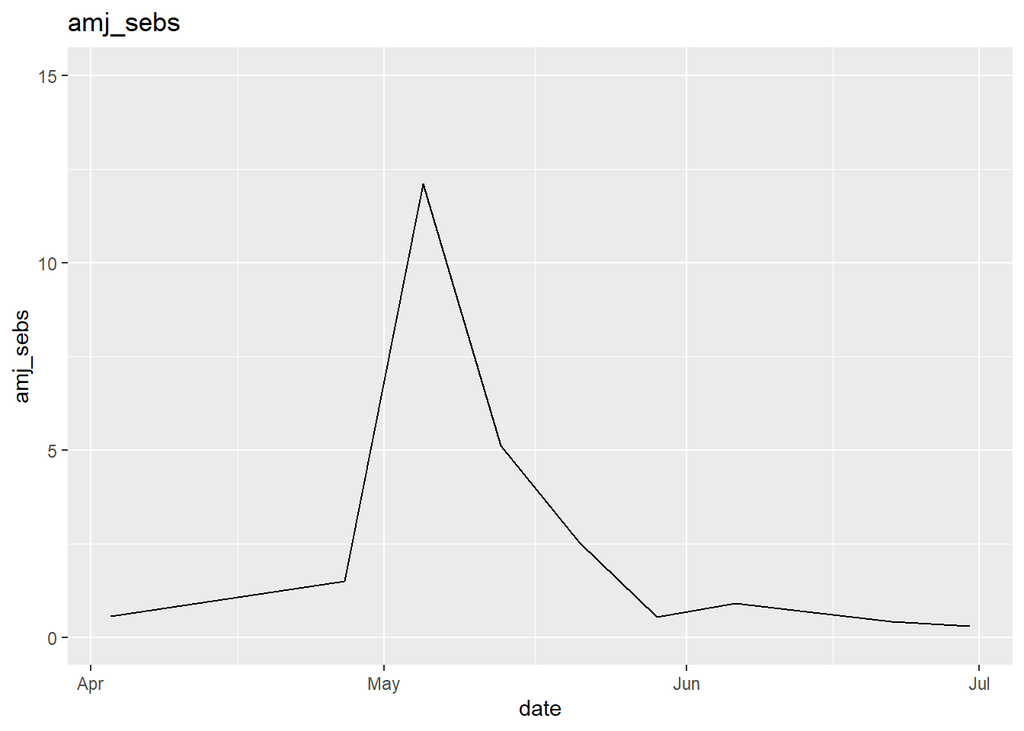

```r
p3
```

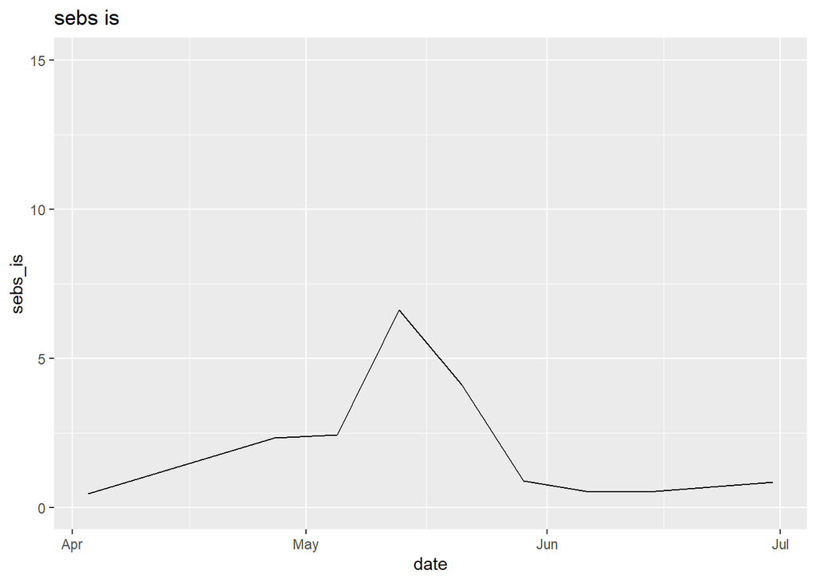

```r
p4
```

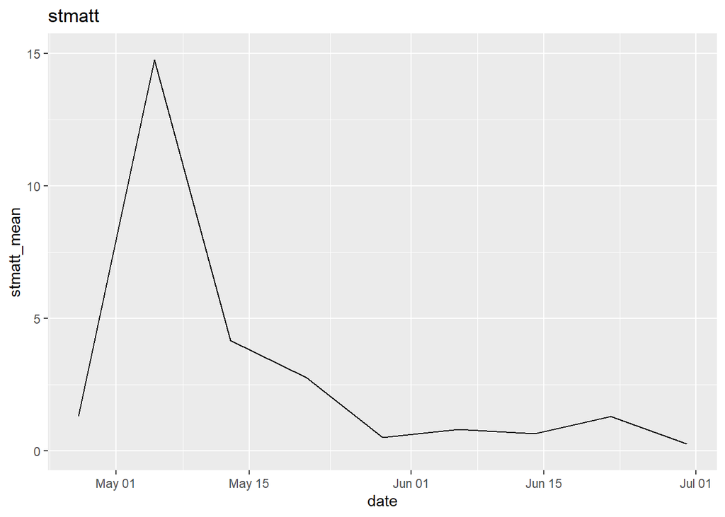

```r
p5
```